# Exercise 2

Holub Martin

03 10 2017

## Exploratory Data Analysis

Do an exploratory data analysis of a matrix of expression values. Load the data and display: * distributions: *boxplot*, *density*, *limma::plotDensities* * normalization: *limma::normalizeQuantiles* * clustering: *hclust* * heatmap: *heatmap.2* or *pheatmap* * correlation matrix: *cor* and *image* * reduced dimensionality representation: *cmdscale* and *prcomp*

*Note: clustering, heatmap, correlation matrix and reduced dimensionality representation are done along both axes of the data matrix (first all samples then 1000 genes with highest variance).*

## Data Import

```r
anno = read.table("SampleAnnotation.txt", as.is=TRUE, sep="\t",
                  quote="", row.names=1, header=TRUE)
x = read.table("expressionData.txt", as.is=TRUE, sep="\t",
               quote="", row.names=1, header=TRUE, check.names = FALSE)
x = as.matrix(x)
```

## Define samples and colors and phenotype

```r
samples = rownames(anno)
colors = rainbow(nrow(anno))
isNorm = anno$TissueType == "norm"
isSick = anno$TissueType == "sick"
isAcute = anno$TissueType == "acute"
```

## Boxplot on a gene expression matrix

Plot a boxplot of log2 transformed data.

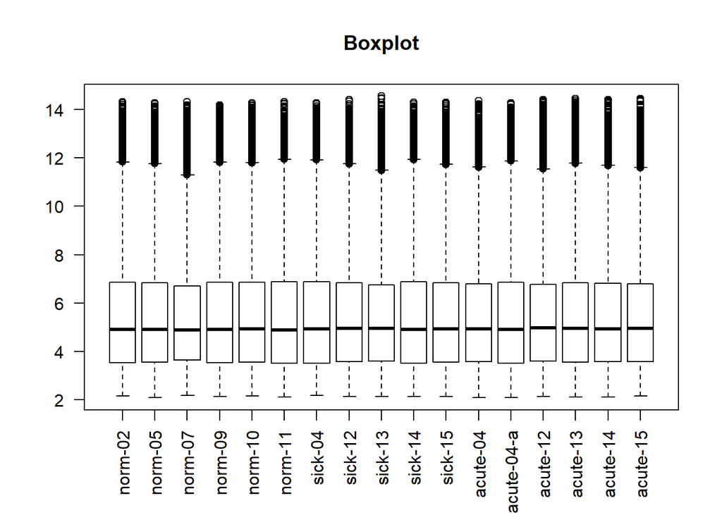

```r
boxplot(log2(x), las = 2, main = "Boxplot", use.cols = TRUE)
```

We see that the boxplots for all samples looks similarl, unsurprisingly as it aggregates information from 54675 genes. We look at othher exploratory plot to probe highly expressed outliers that are of interst for us.

We will **continue working with log2 transfromed data** as this allows for easier comparison of expression levels between genes and samples (more specifically, log2 transformed data coressponds to fold-change in gene expression levels.)

## Kernel Density Estimation

We now plot density estimates of log2 transformed gene expression levels for all samples. We use Gaussian Kernel for smoothing the distances. KDE is somewhat akin to histogram in that it is also a non-parametetric DE estimation method. However it is better suited for data of higher diemnsions and uses a suer-defined kernel for smoothing the result.

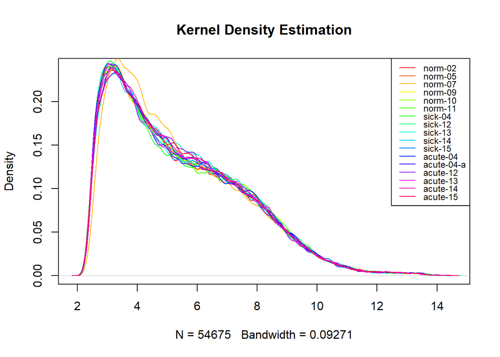

```r
for (i in 1:dim(x)[2]){
  df = density(log2(x[, i]), bw ="SJ", kernel= "gauss", na.rm = TRUE)
  color = colors[i]
  name = samples[i]
  if (i == 1){
    plot(df, col = color, main = "Kernel Density Estimation")
  } else {
    lines(df, col = color)
  } }
legend("topright", legend = samples, col = colors, lwd = 1, cex = 0.75,
       y.intersp = 0.75, ncol = 1)
```

### Use limma::PlotDensities function

Here we can obtain the same plot with an one-liner. Correspondingly with the boxplot we see that most of the mass is located at lower value of expression levels (corresponding to 2-4 fold change). We also notice that there is a bump in the distribution around 8 fold change.

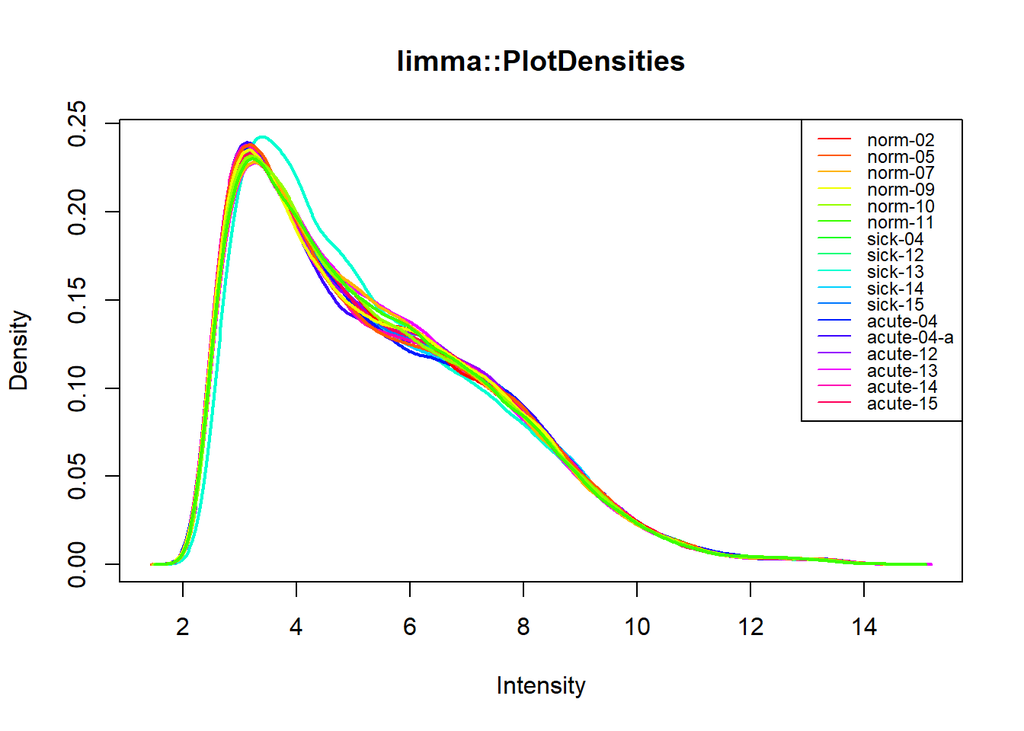

```r
limma::plotDensities(object = log2(x), col = colors, legend = FALSE,
                     main = "limma::PlotDensities")
legend("topright", legend = samples, col = colors, lwd = 1, cex = 0.75,
       y.intersp = 0.75, ncol = 1)
```

When we compare plots produced by *density()* and *limma:PlotDensities()*, we may observe a differnece in smoothnes of individual estimates. This is due to different method for choice of a bandwith. Whereas in the former we use *SJ* [Sheather & Jones (1991)](http://ssg.mit.edu/cal/abs/2000_spring/np_dens/density-estimation/sheather91.pdf) whereas in the latter the default *bw.nrd0* is used. The documentation recommends *SJ*.

It would be interesting to obtain the bandwith for *limma:PlotDensities()*, but it doesn’t appear to be easily accesible.

## Normalize data

Normalize columns of a matrix to have same quantiles and visualize densities. We see that they overlap for all samples indicating quantile allignement. We will keep working with the normalized data.

*Wikipedia has a straighforward example on* [Quantile Normalization](https://en.wikipedia.org/wiki/Quantile_normalization).

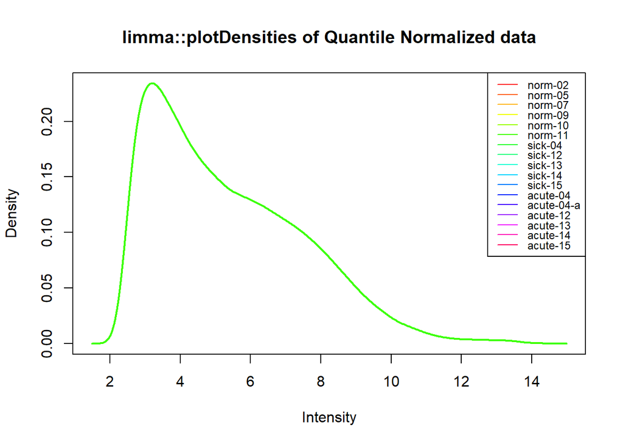

```r
x_norm <- limma::normalizeQuantiles((x))
limma::plotDensities(object = log2(x_norm), col = colors, legend = FALSE,
                     main ="limma::plotDensities of Quantile Normalized data")
legend("topright", legend = samples, col = colors, lwd = 1, cex = 0.75,
       y.intersp = 0.75, ncol = 1)
```

## Hiearchical clustering

Netx, we look at partitioning of samples to clusters. We observe that sick+acute and normal conditions appear together in respective clusters. Sick_14 appears to be an outlier. We use *1 - cor(x,y)* as a distance metric, as discussed in lecture.

*Note1: used method ‘Ward’s minimum variance’ aims at finding compact, spherical clusters.*

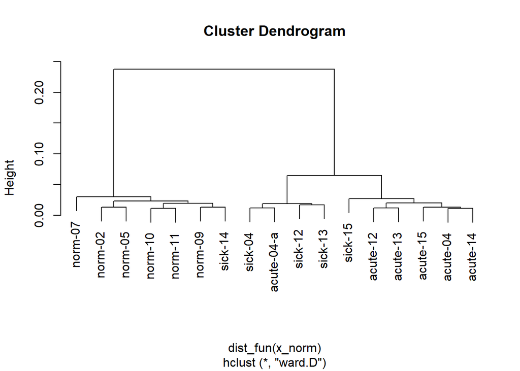

```r
# dist_measure <- as.dist((1-cor(log2(x))))
dist_fun <-function(data){
  # Distance measure based on correlation of log2 transformed data
  data_log2 = log2(data)
  return(as.dist((1-cor((data_log2)))))
}
clusters <- hclust(dist_fun(x_norm), method = "ward.D")
plot(clusters)
```

## Heatmap

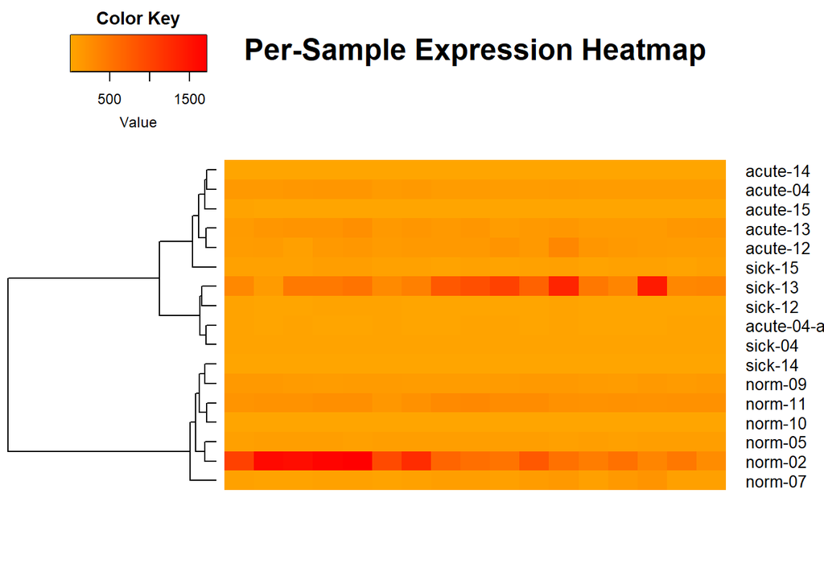

```r
my_palette <- colorRampPalette(c("orange", "red"))(n = 100)
gplots::heatmap.2(x_norm, distfun = dist_fun,
                  dendrogram = "row",
                  Rowv = as.dendrogram(clusters), Colv = "Rowv",
                  labCol = "", labRow = samples,
                  density.info="none",
                  col = my_palette,
                  trace = "none",
                  scale = "none",
                  main = "Per-Sample Expression Heatmap")
```

```r
# We may also use different functions to obtain similar results
# pheatmap::pheatmap(x_norm, main = "HeatMap",
#                    #clustering_distance_rows = dist_fun,
#                    #clustering_distance_cols = dist_fun,
#                    clustering_method = "ward.D",
#                    color = colorRampPalette(c('green', 'orange'))(100),
#                    annotation_row = samples)
```

## Correlation matrix

Next we compute correlations between samples and plot the matrix as an image.

```r
# First, generate some color palette. Later may spend some time to find color-blinded friendly one.
cor_palette = colorRampPalette(c("white", "blue"))(n = 100)

x_corr = cor(log2(x_norm))
```

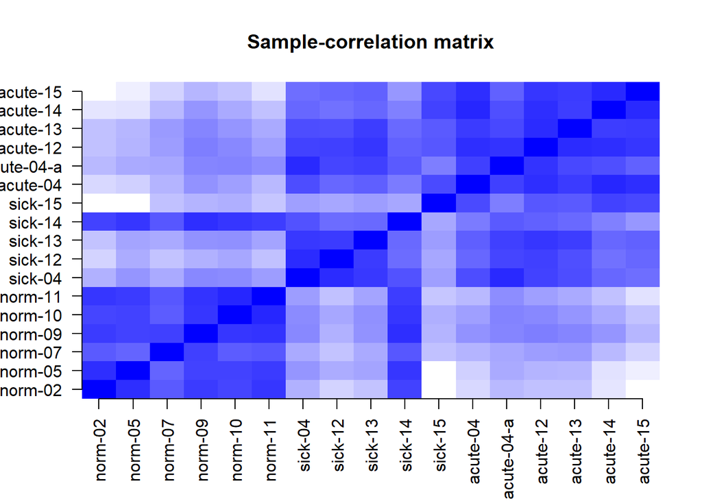

```r
image(x=seq(nrow(x_corr)), y=seq(ncol(x_corr)), z=x_corr,
      main = "Sample-correlation matrix", col = cor_palette,
      xlab = "", ylab = "", axes = F)
axis(1, at=seq(nrow(x_corr)), labels = samples, las=2)
axis(2, at=seq(ncol(x_corr)), labels = samples, las=1)
```

We can also make our lives easier by using dedicated package:

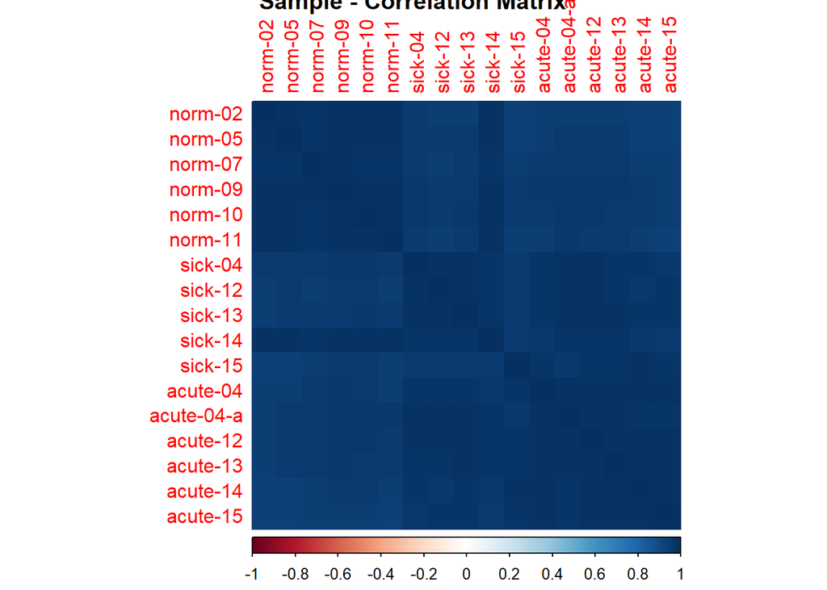

```r
corrplot::corrplot(x_corr, title = "Sample - Correlation Matrix",
                   method = "color", cl.pos="b")
```

Or plotting correlation matrix as a heatmap:

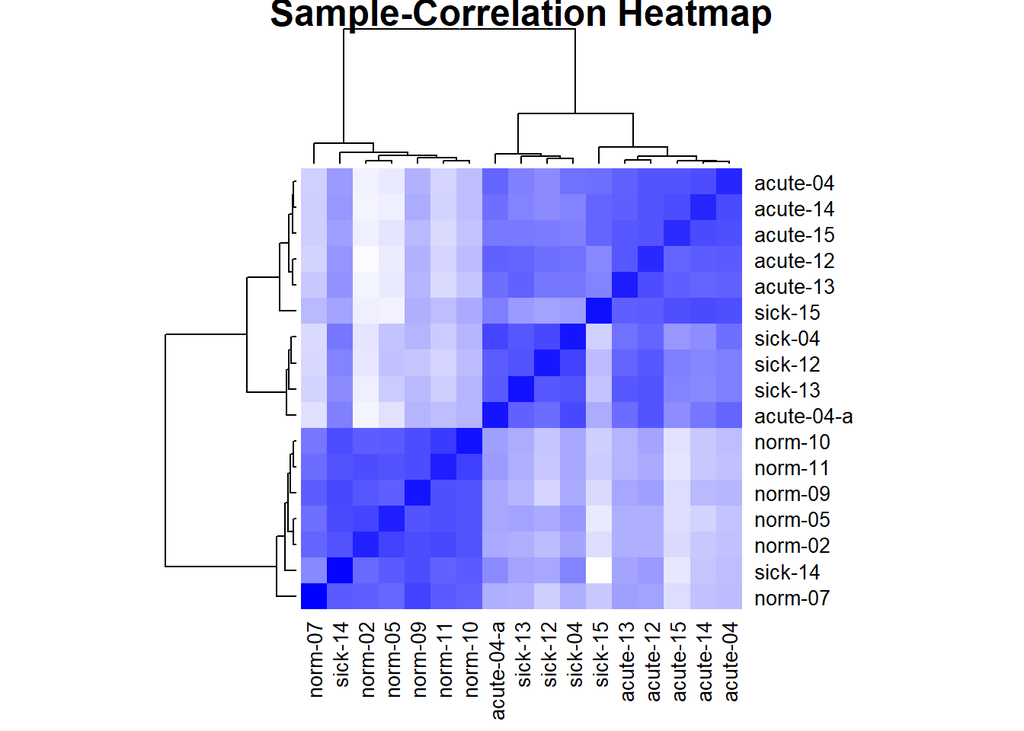

```r
heatmap(x_corr, main = "Sample-Correlation Heatmap", col = cor_palette,
        distfun = dist_fun)
```

We immediately see that plotting of the correlation matrix can be very deceiving, depending on the scale of the colorspace we use. The correlation values range from 0.9304812 to 1, but the first and last shown plot visually suggest much larger differences.Only the second one gives correct representation of correlation values.

*This could be of course corrected for (in cases 1 and 3) by cliping the colormap or showing a colorbar.*

## Dimensionality reduction

First, we take a look at multi-dimensional scaling that tries to preserve distance between individual feature vectors (samples) as well as possible. We reduce the dimensionality to 2 so that we can plot the result in 2D.

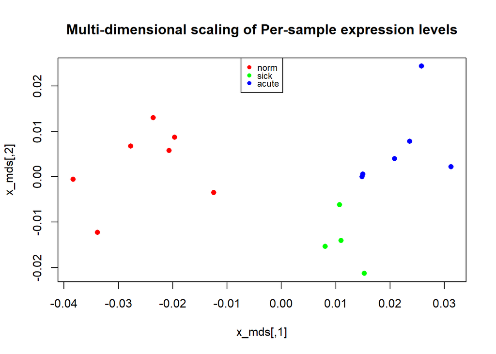

```r
# Get cluster membership from previous clustering
mycl <- cutree(clusters, h=max(clusters$height/4))

#Define Coloring
clusterCols_unique <- rainbow(length(unique(mycl)))
# create vector of colors for legend
clusterCols <- vector(mode = "character", length =length(mycl))
clusterCols[mycl == 1 ] <- clusterCols_unique[1]
clusterCols[mycl == 2 ] <- clusterCols_unique[2]
clusterCols[mycl == 3 ] <- clusterCols_unique[3]

# Do multidimensional scaling
x_mds <- cmdscale(dist_fun(x_norm), k = 2)
plot(x_mds, main = "Multi-dimensional scaling of Per-sample expression levels", col = clusterCols, pch = 16)

names <- c("norm", "sick", "acute")
legend("top",legend = names, col = clusterCols_unique, cex = 0.75,
       y.intersp = 0.75, ncol = 1, pch = 16)
```

Next, we find the coordinate transformation that captures the most of the variance in the first dimensions, ie. we use PCA. We than plot the first two principal components.

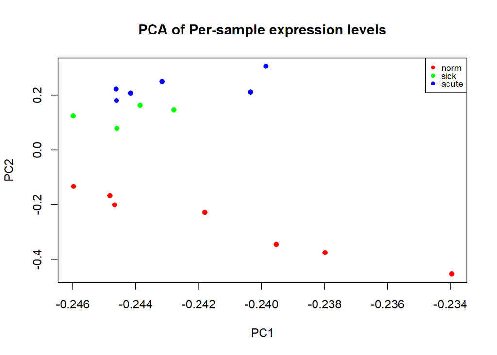

```r
#list[sdev, rotation, x_transformed, center, scale]
pca_res <- prcomp(x = x_norm, center = TRUE, scale = TRUE)
plot(pca_res$rotation[,1:2], main = "PCA of Per-sample expression levels", col = clusterCols, pch = 16)

names <- c("norm", "sick", "acute")
legend("topright",legend = names, col = clusterCols_unique, cex = 0.75,
       y.intersp = 0.75, ncol = 1, pch = 16)
```

Similarly, we observe that samples cluster togetehr according to their condition but the separation is not as obvious as with MDS. We look at 2nd and 3rd PC and see that they give us better representation of disimilarity in the data.

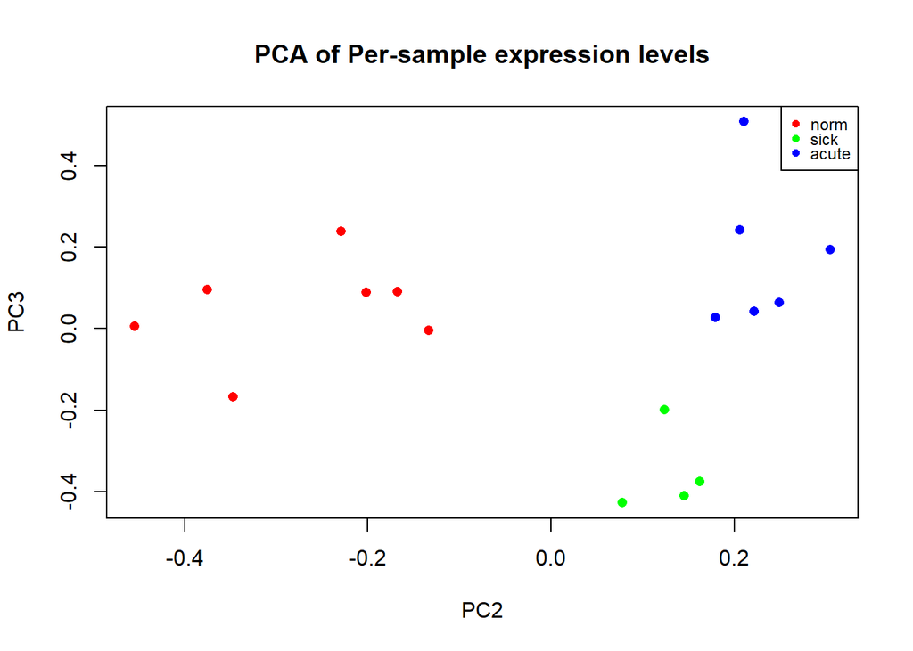

```r
#list[sdev, rotation, x_transformed, center, scale]
pca_res <- prcomp(x = x_norm, center = TRUE, scale = TRUE)
plot(pca_res$rotation[,2:3], main = "PCA of Per-sample expression levels", col = clusterCols, pch = 16)

names <- c("norm", "sick", "acute")
legend("topright",legend = names, col = clusterCols_unique, cex = 0.75,
       y.intersp = 0.75, ncol = 1, pch = 16)
```

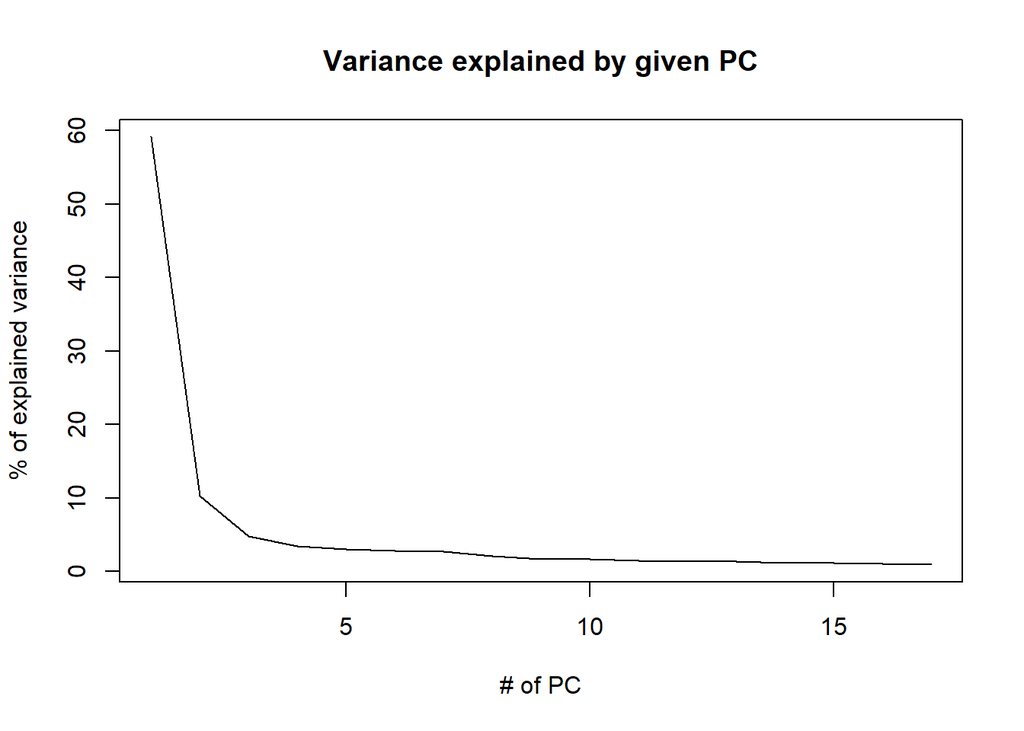

```r
tot_var = sum(pca_res$sdev)
explained_var = pca_res$sdev / tot_var * 100
plot(explained_var, type = 'l', main = 'Variance explained by given PC', xlab = "# of PC", ylab = "% of explained variance")
```

## Redoing parts of the analysis along gene axes

In the previous parts of the exercise (from Hiearchical Clustering onwards) we worked along the “samples” axis of the data. This was because otherwise the computed distance or covariance matrix doesn’t fit into our RAM. Now we adress this issue by **taking 1000 genes from available data that have highest variance and analysing these. We also corespondingly transpose the data**.

*Note: we omit the comments as they would only reiterate what was said before.*

[figure not shown]

```r
# Take 1000 rows with most variance
nv <- apply(x_norm, MARGIN = 1, FUN = var)
x_norm_sample = head( x_norm[order(nv, decreasing = TRUE),] , 1000 )
sample_names = head(samples[order(nv, decreasing = TRUE)], 1000 )
# can also take random 1000
#indices = sample(nrow(x_norm), 1000)
# x_norm_sample = x_norm[indices,]

clusters <- hclust(dist_fun(t(x_norm_sample)), method = "ward.D")
plot(clusters)
```

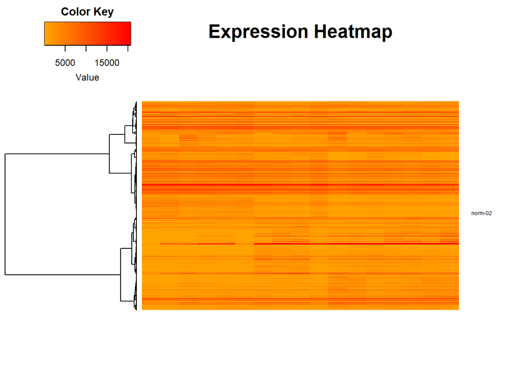

```r
my_palette <- colorRampPalette(c("orange", "red"))(n = 100)
gplots::heatmap.2((x_norm_sample), distfun = dist_fun,
                  dendrogram = "row",
                  Rowv = as.dendrogram(clusters), Colv = FALSE,
                  labCol = "", labRow = sample_names,
                  density.info="none",
                  col = my_palette,
                  trace = "none",
                  scale = "none",
                  main = "Expression Heatmap")
```

```r
# First, generate some color palette. Later may spend some time to find color-blinded friendly one.
cor_palette = colorRampPalette(c("white", "blue"))(n = 100)

x_corr = cor(log2(t(x_norm_sample)))
```

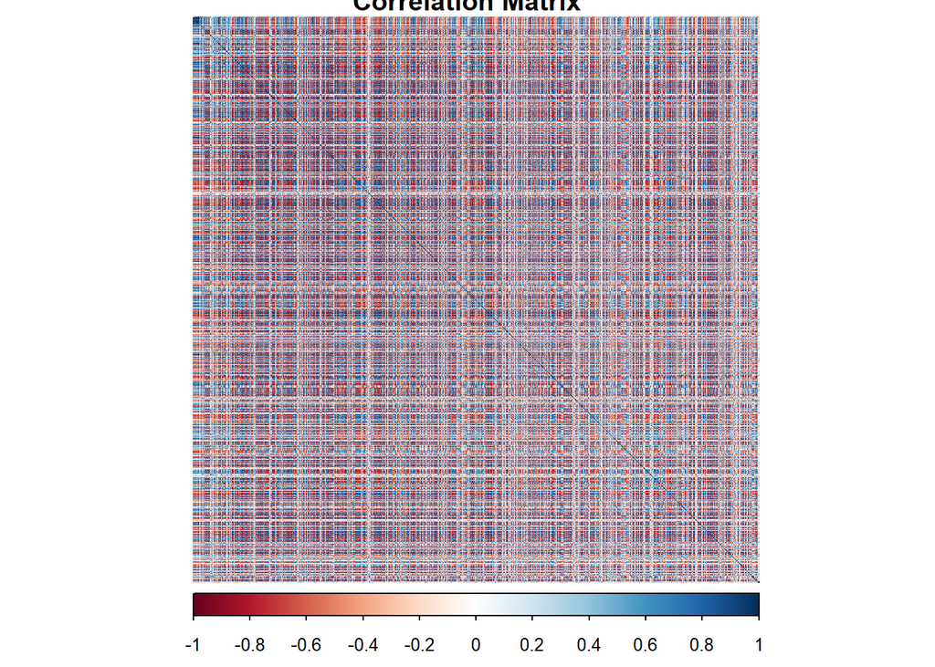

```r
corrplot::corrplot(x_corr, title = "Correlation Matrix",
                   method = "color", cl.pos="b", tl.pos="n")
```

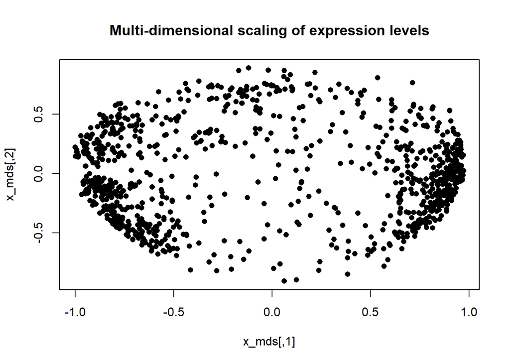

```r
# Do multidimensional scaling
x_mds <- cmdscale(dist_fun(t(x_norm_sample)), k = 2)
plot(x_mds, main = "Multi-dimensional scaling of expression levels", pch = 16)
```

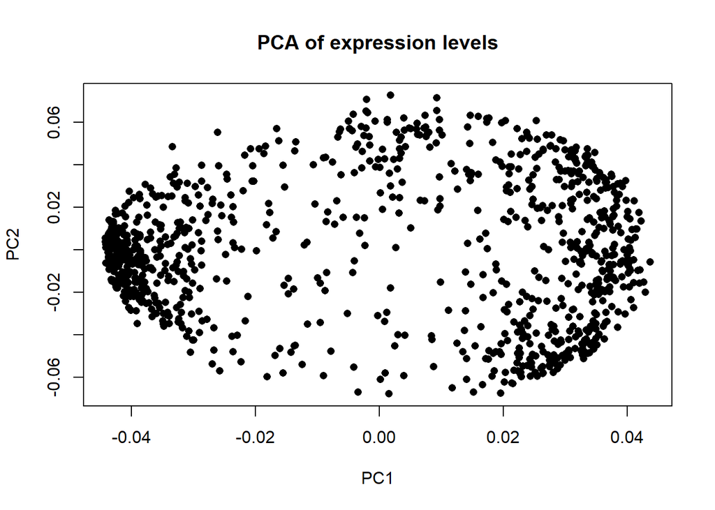

```r
pca_res <- prcomp(x = t(x_norm_sample), center = TRUE, scale = TRUE)
plot(pca_res$rotation[,1:2], main = "PCA of expression levels", pch = 16)
```

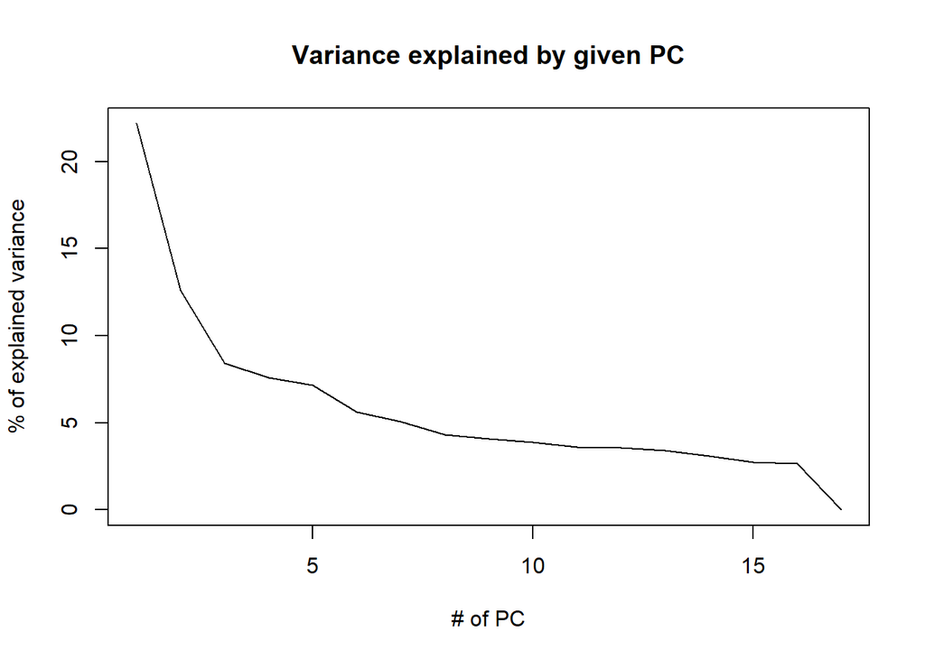

```r
tot_var = sum(pca_res$sdev)
explained_var = pca_res$sdev / tot_var * 100
plot(explained_var, type = 'l', main = 'Variance explained by given PC', xlab = "# of PC", ylab = "% of explained variance")
```

## Conclusion

This concludes homework #2. We have learned how to apply basic data exploratory techniques and used those on dataset of gene expression levels for 3 conditions and 17 samples. We have also brushed up on our R skills.